# Comparing persistence diagrams

persistence_landscape() and bottleneck_distance()

honets

2026-08-26

## The analytic question

A persistence diagram is a *multiset of points* — not a vector, not a function. You cannot average two of them, feed one to a regression, or compute a standard deviation across a sample. That is inconvenient the moment you want to compare two datasets rather than describe one.

Two verbs solve it in different ways:

- **`bottleneck_distance()`** gives a *metric*: how far apart are these two diagrams? Good for a direct comparison, and it is the classical stability distance for persistence.
- **`persistence_landscape()`** gives a *function*: it re-encodes the diagram as a sequence of piecewise-linear functions living in a vector space, where averaging and statistics are ordinary operations.

```r
library(honets)
mk <- function(seed) {
  set.seed(seed)
  m <- matrix(runif(100), 10, 10)
  m <- (m + t(m)) / 2
  diag(m) <- 0
  dimnames(m) <- list(LETTERS[1:10], LETTERS[1:10])
  persistent_homology(m, n_steps = 12, max_dim = 2)
}
ph  <- mk(1)
ph2 <- mk(9)
```

## Bottleneck distance

```r
bottleneck_distance(ph, ph2)
```

```
     dim_0      dim_1      dim_2
0.10570661 0.09403464 0.12921179
```

One value per dimension: components, loops, voids. These two random networks differ most in dimension 2 (0.129) and least in dimension 1 (0.094).

Restrict to a single dimension with `dimension =`:

```r
bottleneck_distance(ph, ph2, dimension = 1)
```

```
     dim_1
0.09403464
```

### It is a metric, and you should check that

```r
# identity of indiscernibles: d(x, x) = 0
bottleneck_distance(ph, ph)
```

```
dim_0 dim_1 dim_2
    0     0     0
```

```r
# symmetry: d(x, y) = d(y, x)
identical(bottleneck_distance(ph, ph2), bottleneck_distance(ph2, ph))
```

```
[1] TRUE
```

Both hold exactly. The bottleneck distance is the smallest ε such that the two diagrams can be matched within ε, allowing unmatched points to pair with the diagonal — which is what makes it robust to the short-lived noise features that clutter every diagram.

## Persistence landscapes

A landscape converts the diagram into `k_max` functions. The first, `k = 1`, traces the most persistent feature at each scale; `k = 2` the second-most, and so on.

```r
pl <- persistence_landscape(ph, k_max = 3, dimension = 1)
pl
```

```
Persistence Landscape (dimension 1, k_max = 3)
  Evaluated at 200 grid points in [0.4918, 0.6902]
  Sup norms by k: k1=0.0987  k2=0.0936  k3=0.0609
```

```r
as.data.frame(pl, top = 4)
```

```
  k         t        value
1 1 0.4918348 0.0000000000
2 1 0.4928316 0.0009968344
3 1 0.4938284 0.0019936688
4 1 0.4948253 0.0029905032
```

One row per (level, grid point). Restrict to one level with `k =`:

```r
as.data.frame(pl, k = 1, top = 3)
```

```
  k         t        value
1 1 0.4918348 0.0000000000
2 1 0.4928316 0.0009968344
3 1 0.4938284 0.0019936688
```

```r
nrow(as.data.frame(pl, k = 1))
```

```
[1] 200
```

200 grid points per level, which is `t_grid`’s default resolution.

## Plotting

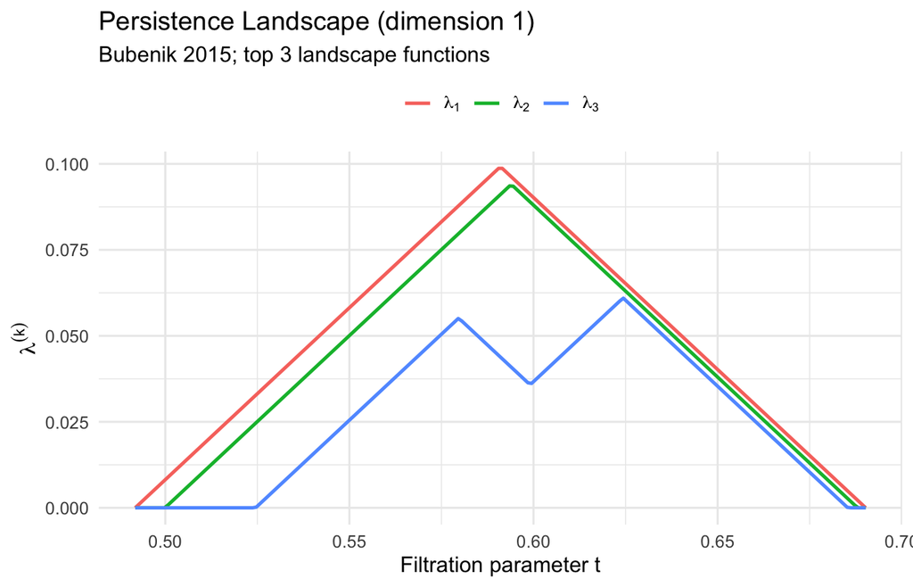

```r
plot(pl)
```

## Why a landscape rather than a diagram

Because it lives in a vector space, a landscape supports operations a diagram does not:

```r
l1 <- as.data.frame(persistence_landscape(ph,  k_max = 2, dimension = 1), k = 1)
l2 <- as.data.frame(persistence_landscape(ph2, k_max = 2, dimension = 1), k = 1)

# the two landscapes are evaluated on different grids by default
range(l1$t)
```

```
[1] 0.4918348 0.6902048
```

```r
range(l2$t)
```

```
[1] 0.4520990 0.6070456
```

Note the grids differ — each landscape is evaluated over its own diagram’s range. **To average or subtract landscapes, put them on a common grid** with `t_grid`:

```r
g <- seq(0.45, 0.75, length.out = 100)
a <- as.data.frame(persistence_landscape(ph,  k_max = 2, dimension = 1, t_grid = g), k = 1)
b <- as.data.frame(persistence_landscape(ph2, k_max = 2, dimension = 1, t_grid = g), k = 1)

mean_landscape <- data.frame(t = g, value = (a$value + b$value) / 2)

# L2 distance between the two, on the shared grid
sqrt(sum((a$value - b$value)^2) * diff(g)[1])
```

```
[1] 0.02211789
```

A mean landscape is a landscape, so it plots like one:

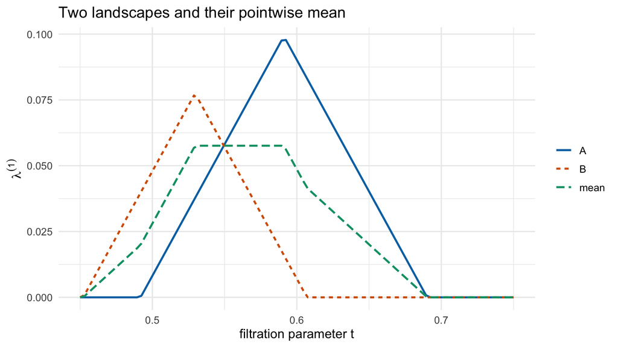

```r
both <- rbind(
  data.frame(t = g, value = a$value,           landscape = "A"),
  data.frame(t = g, value = b$value,           landscape = "B"),
  data.frame(t = g, value = mean_landscape$value, landscape = "mean")
)
ggplot2::ggplot(both, ggplot2::aes(x = t, y = value,
                                   colour = landscape, linetype = landscape)) +
  ggplot2::geom_line(linewidth = 0.9) +
  ggplot2::scale_colour_manual(
    values = c(A = "#0072B2", B = "#D55E00", mean = "#009E73")) +
  ggplot2::labs(x = "filtration parameter t", y = expression(lambda^(1)),
                colour = NULL, linetype = NULL,
                title = "Two landscapes and their pointwise mean") +
  ggplot2::theme_minimal(base_size = 12)
```

## Choosing between them

- **`bottleneck_distance()`** — comparing two datasets, or checking stability under perturbation. Returns one interpretable number per dimension. Slower on large diagrams, since it solves a matching problem.
- **`persistence_landscape()`** — many datasets, or any analysis needing means, variances or a regression. Fix `t_grid` across the sample, or the results are not comparable.

## What to do next

- **`persistent_homology()`** — where the diagrams come from.
- **`betti_numbers()`** — the single-threshold summary these methods generalise.

## References

- Bubenik, P. (2015). Statistical topological data analysis using persistence landscapes. *Journal of Machine Learning Research*, 16, 77-102.
- Cohen-Steiner, D., Edelsbrunner, H., & Harer, J. (2007). Stability of persistence diagrams. *Discrete & Computational Geometry*, 37(1), 103-120.
- Kerber, M., Morozov, D., & Nigmetov, A. (2017). Geometry helps to compare persistence diagrams. *ACM Journal of Experimental Algorithmics*, 22.